## Project: Amazon product review Data Analysis

## Author: Suyash Gautam

## This project is about working with Amazon Product review data set using R’s data manipulation techniques to find suspicious points in the data set.

## FILE IMPORT

```r
amazonReviews <- read.csv("~/Documents/R_dir/amazonReviews.csv")
head(amazonReviews)
```

```
##   id   productId          userId     profileName helpfulness score
## 1  1  B002MXSAD2   A50FYNAOYJCGX             Moo         0/0     5
## 2  2  B0013TAI90   A2H9ZWA1XGUR6  Coffee Drinker         0/1     5
## 3  3  B000W5SLB8  A1NDSM7Y7U2PWV           Rhian         2/5     3
## 4  4  B0078Y6OX8  A3936J8U8H5JH7  Lara R. Lovett         2/2     3
## 5  5  B005K4Q1VI  A1Q7232KST2VWE         Rob  S.         0/0     2
## 6  6  B002QWP89S  A1FW9S8HRPTBMB        D. Dixon         0/0     5
##         time
## 1 1337617066
## 2 1358479642
## 3 1286125517
## 4 1354262717
## 5 1384424870
## 6 1355608742
```

```r
View(amazonReviews)
```

## SOME DATA TRANSFORMATION

It seems that the input dates/times are stored as the number of seconds from January 1, 1970. I used the structure command to create the POSIX date values and transformed the ‘time’ variable in the data set.

```r
newtime <- structure(amazonReviews$time, class=c('POSIXt','POSIXct'))
head(newtime)
```

```
## [1] "2012-05-21 12:17:46 EDT" "2013-01-17 22:27:22 EST"
## [3] "2010-10-03 13:05:17 EDT" "2012-11-30 03:05:17 EST"
## [5] "2013-11-14 05:27:50 EST" "2012-12-15 16:59:02 EST"
```

```r
amazonReviews$time <- newtime
class(newtime)
```

```
## [1] "POSIXt"  "POSIXct"
```

Now time is in the proper format. Specific months and weekdays can be easily extracted from the time variable for further analysis

# Dealing with ‘helpfulness’ variable.

```r
h <- amazonReviews$helpfulness
head(h)
```

```
## [1]  0/0  0/1  2/5  2/2  0/0  0/0
## 845 Levels:  0/0  0/1  0/10  0/11  0/12  0/13  0/14  0/15  0/16 ... 9/9
```

```r
class(h)
```

```
## [1] "factor"
```

The helpfulness variable is a factor variable and needs to be converted into a numeric variable to analyze

```r
ch <- as.character(h)
class(ch)
```

```
## [1] "character"
```

```r
newh <- sapply(strsplit(ch, "/"),
               function(ch) {
                 ch <- as.numeric(ch);
                 100 * ch[1] / ch[2]
                 })
head(newh)
```

```
## [1] NaN   0  40 100 NaN NaN
```

```r
class(newh)
```

```
## [1] "numeric"
```

```r
amazonReviews$helpfulness <- newh
```

Now the helpfulness scores have been converted to numeric format(percentage) and can be ananlysed further. Although there are a lot of NAN’s in the helpfulness value that resulted from division by 0, I will skip that part for the purposes of this research.

Lets summarize score and helpfulness

```r
summary(amazonReviews$score)
```

```
##    Min. 1st Qu.  Median    Mean 3rd Qu.    Max.
##   1.000   4.000   5.000   4.151   5.000   5.000
```

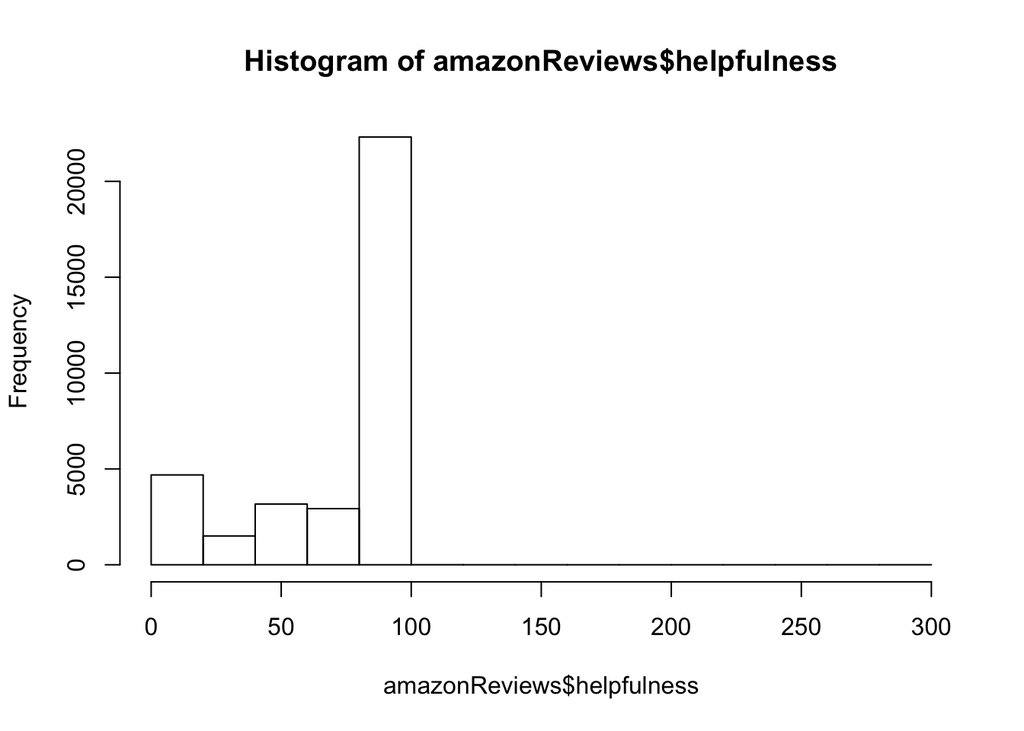

```r
hist(amazonReviews$helpfulness)
```

```r
summary(amazonReviews$helpfulness)
```

```
##    Min. 1st Qu.  Median    Mean 3rd Qu.    Max.    NA's
##     0.0    50.0   100.0    76.3   100.0   300.0   30927
```

The summary of the helpfulness variable shows that there are a few values with a helpfulness score greater than 100%. This is unlikely and suspicious. Let’s subset the data to see these values

```r
s <- subset(amazonReviews, newh > 100)
head(s)
```

```
##          id   productId          userId              profileName
## 112     112  B000LRKO9E   ATQ7DL7RKN0PI           Mary A. Parham
## 1199   1199  B000SDMFC0   AP2BGZEHZU3TA               Ana Borges
## 1730   1730  B002BCD2GO  A2K3ELBPTKNTTM                    Ponyo
## 44899 44899  B001EQ55RW  A2V0I904FH7ABY                      Ram
## 61975 61975  B000OU5EKC   AVFA1JB08RG8G   Wile E. Coyote "^. .^"
## 64891 64891  B000MIDROQ  A161DK06JJMCYF  J. E. Stephens "Jeanne"
##       helpfulness score                time
## 112      125.0000     5 2008-06-13 16:32:38
## 1199     120.0000     3 2010-10-29 12:55:12
## 1730     105.5556     4 2012-07-29 17:00:00
## 44899    150.0000     4 2009-09-14 02:05:46
## 61975    107.1429     5 2011-08-22 18:48:00
## 64891    300.0000     5 2009-06-22 20:12:58
```

## SUSPICIOUS DATA POINT 2 - FUTURE DATES/ Possible fraudsters

# Working with time data

```r
summary(newtime)
```

```
##                  Min.               1st Qu.                Median
## "1969-12-31 19:00:00" "2011-02-15 19:56:09" "2012-05-29 14:14:24"
##                  Mean               3rd Qu.                  Max.
## "2012-01-31 22:01:58" "2013-04-19 02:00:00" "2037-04-18 14:45:07"
```

The sumamry shows that there are reviews made in the year 2037. This is impossible and arouses suspicioun.

```r
library(plyr)
t <- subset(amazonReviews, newtime > "2014-12-31")
t1 <- arrange(t, desc(time))
head(t1)
```

```
##      id   productId          userId                   profileName
## 1 26344  B001EO5YAC  A2W4ICKG1WMHXG                      Caroline
## 2 39930  B000POUIOE  A36RQ8DLJOS1CI  grandmother L. "bread baker"
## 3 63661  B000POUIOE  A2KC1UCQYX0G3L                      H. Cheng
## 4 17674  B000POUIOE   AS1D77NND22CY            Reiner Girl "Mona"
## 5  6443  B000POUIOE  A1CLNW3WKFWD6A                    Jacquieann
## 6 30104  B000POUIOE  A3F7NO1Q3RQ9Y0                       Juiblex
##   helpfulness score                time
## 1         NaN     3 2037-04-18 14:45:07
## 2    88.88889     3 2018-10-12 15:48:22
## 3    50.00000     3 2018-08-22 19:14:37
## 4   100.00000     4 2018-07-19 21:32:06
## 5    50.00000     5 2018-06-15 23:49:36
## 6    72.72727     3 2018-04-26 03:15:50
```

```r
View(t1)
#randomt <- t[sample(1:nrow(t), 500, replace = FALSE), 4:7 ]
#View(randomt)
```

The data looks alright up until the end of 2015. Lets subset it further to reveal only 2016 data

```r
t2 <- subset(amazonReviews, newtime > "2015-12-31")
t3 <- arrange(t2, desc(time))
head(t3)
```

```
##      id   productId          userId                   profileName
## 1 26344  B001EO5YAC  A2W4ICKG1WMHXG                      Caroline
## 2 39930  B000POUIOE  A36RQ8DLJOS1CI  grandmother L. "bread baker"
## 3 63661  B000POUIOE  A2KC1UCQYX0G3L                      H. Cheng
## 4 17674  B000POUIOE   AS1D77NND22CY            Reiner Girl "Mona"
## 5  6443  B000POUIOE  A1CLNW3WKFWD6A                    Jacquieann
## 6 30104  B000POUIOE  A3F7NO1Q3RQ9Y0                       Juiblex
##   helpfulness score                time
## 1         NaN     3 2037-04-18 14:45:07
## 2    88.88889     3 2018-10-12 15:48:22
## 3    50.00000     3 2018-08-22 19:14:37
## 4   100.00000     4 2018-07-19 21:32:06
## 5    50.00000     5 2018-06-15 23:49:36
## 6    72.72727     3 2018-04-26 03:15:50
```

```r
# View(t3)
```

After looking at the ‘t3’ data set, it is evident that there are a huge number of product reviews asociated with id “B000POUIOE”, a few with id “B00099XOQO” and one with “B001EO5YAC”. All these reviews have dates in the future and are all good reviews ranging from 3 to 5. These productId’s have different user ID’s possibly hinting that these users were paid to write fake reviews.

These findings can help identify fraudulent sellers and should be kept in seperate records. They should not be part of analysis of the genuine product review data.

## SUSPICIOUS DATA POINT 3 - Possible automated account

Another strange thing I found sifting through the ‘t1’ subset was that a majority of these entries belong to profileName “AnonReviewer” with userID “AZQ4A457E5GWJ02”. Lets go deeper and subset the data with just this profileName.

```r
reviewer <- subset(amazonReviews, profileName == "AnonReviewer")
View(reviewer)
nrow(reviewer)
```

```
## [1] 233
```

```r
reviewer2 <- arrange(reviewer, desc(time))
head(reviewer2)
```

```
##      id   productId           userId  profileName helpfulness score
## 1  4871  B004ADXW8A  AZQ4A457E5GWJ02 AnonReviewer     0.00000     5
## 2 38045  B001HTG3IQ  AZQ4A457E5GWJ02 AnonReviewer    16.66667     5
## 3  1535  B0047IG6OU  AZQ4A457E5GWJ02 AnonReviewer     0.00000     5
## 4  7558  B00817GPWQ  AZQ4A457E5GWJ02 AnonReviewer     0.00000     5
## 5  8385  B000UBDKII  AZQ4A457E5GWJ02 AnonReviewer     0.00000     5
## 6 11443  B0085G4ACA  AZQ4A457E5GWJ02 AnonReviewer    20.00000     5
##                  time
## 1 2015-11-15 15:11:30
## 2 2015-11-15 15:11:30
## 3 2015-10-30 07:06:58
## 4 2015-10-30 07:06:58
## 5 2015-10-30 07:06:58
## 6 2015-10-30 07:06:58
```

So the AnonReviewer wrote 233 reviews. When ordered by time, we see that reviews for more than one productID were made at the same time. As an example, ID’s “B00469VTOW”, “B00434FTDM”, “B00060PTLO”, “B0015R9BQG”, “B004M0Y8T8” were reviewed by AnonReviewer on 2015-03-31 eaxctly at 09:08:07. That’s not possible, not by a human anyway. This confirms that AnonReviewer is a bot/script and has probably written fake reviews. Removing these observations from the data set is recommended.